# PRINCIPIOS DE DISEÑO EXPERIMENTAL: ANÁLISIS DE VARIANZA DE UNA VÍA (ONE-WAY ANOVA)

JOSÉ M. GÓMEZ

9/11/2021

# A. FUNDAMENTOS TEÓRICOS GENERALES DEL DISEÑO DE EXPERIMENTOS

## A1. Conceptos Fundamentales: Diseño Experimental, Factor, Niveles, Tratamiento, Unidad Experimental y Variables Confusoras

Incluye el diseño de todos los ejercicios de recolección de información donde hay variación y donde el experimentador puede tener completo control o no. El experimentador está interesado en el efecto de algún proceso o intervención llamado *tratamiento* sobre algunos objetos llamados *unidades experimentales*.

En este contexto, un *factor* es una variable categórica (o categorizada) con varios niveles para la cual se quiere investigar el efecto que tiene un cambio en ella sobre una variable respuesta. Los factores tienen “niveles” de aplicación, donde los niveles implican una cantidad o magnitud; i.e, si se les aplica dosis de 5mg, 10mg y 15mg de un medicamento a las unidades experimentales, estas cantidades son los niveles del factor. También se usa el término “nivel” para variables categóricas; i.e, en un experimento donde se prueban tres tipos de droga, cada tipo de droga administrada es un nivel del factor (A, B, o C).

En experimentos, un tratamiento es algo que los investigadores administran a las unidades experimentales. Cuando un experimento tiene un solo factor los tratamientos son los niveles del factor, en cambio, si el experimento tiene dos o más factores, cada tratamiento es la combinación de los niveles de los factores. Las unidades experimentales pueden ser personas, ratas, muestras de material, pedazos de tierra o paquetes de salchichas con las que el investigador trabaja y a las que se les aplica los tratamientos bajo estudio. Una *variable confusora* está relacionada tanto con la pertenencia al grupo como con la respuesta. Su presencia hace difícil establecer que la respuesta sea consecuencia directamente de la pertenencia al grupo. Así, una variable confusora es una variable que influencia tanto a los predictores como a la respuesta y que conduce a asociación espuria.

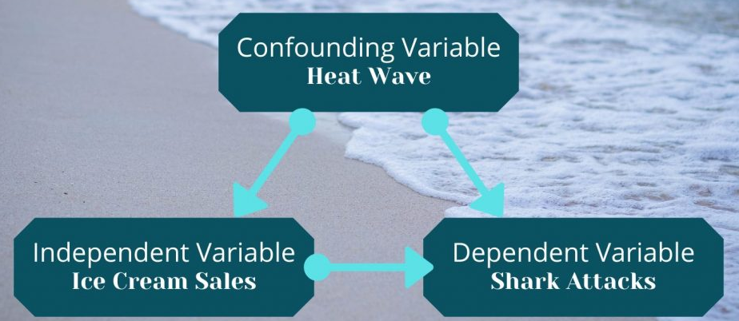

```r
knitr::include_graphics("IMG1.png")
```

```r
#Figura 1: Variables Confusoras (Confounding Variables)
#Fuente: https://sciencenotes.org/what-is-a-confounding-variable-definition-and-examples/
```

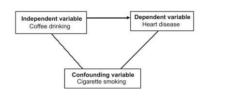

```r
knitr::include_graphics("IMG2.png")
```

```r
#Figura 2: Variables Confusoras (Confounding Variables)
#Fuente: https://www.sciencedirect.com/topics/nursing-and-health-professions/confounding-variable
```

## A2. Consideraciones en el Diseño de Experimentos

Aunque no se requiere tener igual cantidad de unidades experimentales bajo cada tratamiento, la potencia de las pruebas de hipótesis aumenta conforme las muestras tengan tamaños tan parecidos como sea posible. El desempeño de las pruebas será mejor conforme las unidades experimentales sean más similares en todos los aspectos excepto en el tratamiento aplicado; sin embargo, para obtener resultados más generalizables se pueden incluir factores de ruido controlables o medibles que pueden ser considerados en el modelo. En un diseño totalmente experimental, cada unidad experimental debe ser asignada aleatoriamente a cada uno de los tratamientos bajo estudio. En la práctica no siempre es posible hacer una asignación aleatoria de las unidades a los tratamientos. Esto limita el alcance del diseño. Los factores de ruido que no se pueden controlar se deben medir para tomarse en cuenta en el momento del análisis de tal forma que no oscurezcan los resultados.

## A3. Aleatorización

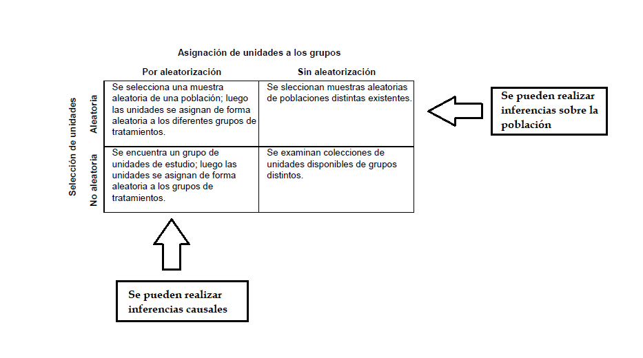

```r
knitr::include_graphics("IMG3.png")
```

```r
#Figura 3: Sobre la Aleatorización en el Diseño de Experimentos
#Fuente: Ricardo Alvarado Barrantes. Diseño de Experimentos, Capítulo IV: Diseños en un factor. p. 14.
```

## A4. Error Experimental

Las diferencias entre unidades experimentales que están bajo un mismo tratamiento se atribuye solamente a un error experimental aleatorio o a la presencia de un factor de ruido no considerado en el experimento que esté causando variaciones. Aún cuando se incluyan todos los factores que puedan estar influyendo la respuesta, se espera que exista variación entre unidades experimentales que están bajo un mismo tratamiento. El error experimental es inherente a todo proceso.

## A5. Descomposición de Suma de Cuadrados Totales

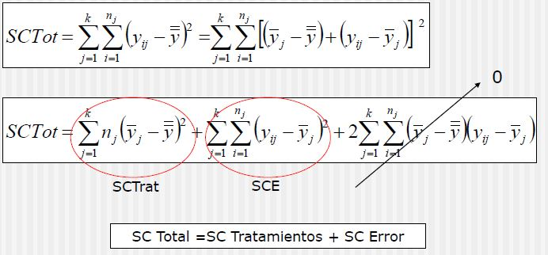

```r
knitr::include_graphics("IMG4.JPG")
```

```r
#Figura 4: Descomposición de la Suma de Cuadrados Totales del Tratamiento
#Fuente: Ricardo Alvarado Barrantes. Diseño de Experimentos, Capítulo IV: Diseños en un factor. p. 38.
```

## A6. Distribución de Probabilidad de las Sumas de Cuadrados y Teorema de Cochran

En 1934 William Cochran publicó en *Mathematical Proceedings of the Cambridge Philosophical Society* (p. 178-191) una investigación titulada “The distribution of quadratic forms in a normal system, with applications to the analysis of covariance”, en la cual establecía un teorema para justificar formalmente los resultados relativos a las distribuciones de probabilidad que se usan para realizar Análisis de Varianza (ANOVA).

Como señala Cochran (p. 178), muchas de las aplicaciones más utilizadas de la teoría de la estadística, como por ejemplo los métodos de análisis de varianza y covarianza, la prueba general de regresión múltiple y la prueba de un coeficiente de regresión, dependen esencialmente de la distribución conjunta de varias formas cuadráticas. en un sistema normal univariado. El objetivo de la investigación de Cochran fue probar los principales resultados relevantes sobre esta distribución. Adicionalmente, como aplicación de estos resultados, profundiza en la teoría involucrada en el método de análisis de covarianza. El sistema probabilístico normal usado por Cochran es uno tal que las regresoras son independientes e idénticamente distribuidas, normales de media nula y varianza unitaria, y válido para todo tipo de formas cuadráticas; una forma cuadrática es un polinomio con términos todos de grado dos (“forma” es otro nombre para un polinomio homogéneo). Por ejemplo, $4x^2 + 2xy - 3y^2$ es una forma cuadrática en las variables x e y). A estas formas cuadráticas Cochran las denota como $Q_i$ (p. 178).

El teorema de Cochran establece que las formas cuadráticas $Q_i$ son independientes y cada una de ellas tiene una distribución chi-cuadrado con $r_i$ grados de libertad, en donde los grados de libertad son calculados como el rango de la matriz en la que se expresa cada forma cuadrática. De manera menos formal, tales grados de libertad son el número de combinaciones lineales incluidas en la suma de cuadrados que definen $Q_i$, siempre que estas combinaciones lineales sean linealmente independientes (p. 180)

Así, la suma de cuadrados totales sigue una distribución $χ^2$ con $n-1$ grados de libertad, la suma de cuadrados del tratamiento sigue una distribución $χ^2$ con $k-1$ grados de libertad y, finalmente, la suma de cuadrados del error sigue una distribución $χ^2$ con $n-k$ grados de libertad, donde $k$ es el número de coeficientes de regresión a estimar (que representan los efectos y la media global -equivalente al intercepto de un modelo econométrico-).

## A7. Contraste de Hipótesis

En este contexto, el contraste de hipótesis consiste en verificar si la medias obtenidas bajo todos los tratamientos son iguales o si, por el contrario, al menos uno de los tratamientos produce un promedio diferente a los demás. En tal caso se dice que el factor tiene un efecto sobre la media global de la variable respuesta. Se busca determinar si al menos un par de tratamientos producen medias estadísticamente diferentes entre sí.

# B. CASO DE APLICACIÓN: ANÁLISIS DEL PROCESO DE OXIDACIÓN DE LAS MANZANAS

## B1. Efectos Individuales y Efectos Agregados en los Tratamientos

Las manzanas tienen un compuesto llamado polifenol oxidasa, el cual hace que se oscurezcan rápidamente en contacto con el aire una vez cortadas, que es como se presenta visualmente el proceso su oxidación. Para evitar el pardeamiento, se probaron tres tratamientos: 1) taparla, 2) ponerla en bolsa plástica cerrada, y 3) aplicarle jugo de limón. Se incluyó además un control sin aplicar nada (4). Una vez aplicados los tratamientos el resultado fue evaluado por 10 jueces que calificaron el color en una escala de 1 a 6, donde 1 es el color normal de la fruta y 6 es el más oscuro. El objetivo final es seleccionar el tratamiento que mantenga mejor el color original para una empresa que se encarga de banquetes para altos ejecutivos.

En un primer análisis, sólo interesa investigar si existe alguna diferencia en el color promedio resultante con los cuatro tratamientos. Para ello, es recomendable definir correctamente el factor y aplicar las etiquetas correspondientes a cada tratamiento; este archivo así creado puede guardarse en el disco duro del equipo para ser utilizado en futuras ocasiones.

```r
base=read.csv("manzanas.csv",sep=";")
base$trat
```

```
##  [1] 1 1 1 1 1 1 1 1 1 1 2 2 2 2 2 2 2 2 2 2 3 3 3 3 3 3 3 3 3 3 4 4 4 4 4 4 4 4
## [39] 4 4
```

```r
base$trat=factor(base$trat)
levels(base$trat)=c("tapar","bolsa","limón","control")
base$trat
```

```
##  [1] tapar   tapar   tapar   tapar   tapar   tapar   tapar   tapar   tapar
## [10] tapar   bolsa   bolsa   bolsa   bolsa   bolsa   bolsa   bolsa   bolsa
## [19] bolsa   bolsa   limón   limón   limón   limón   limón   limón   limón
## [28] limón   limón   limón   control control control control control control
## [37] control control control control
## Levels: tapar bolsa limón control
```

```r
save(base,file="manzanas.Rdata")
attach(base)
```

Con la finalidad de realizar un estudio preliminar sobre los efectos de cada tratamiento en la variable de respuesta, puede construirse un boxplot.

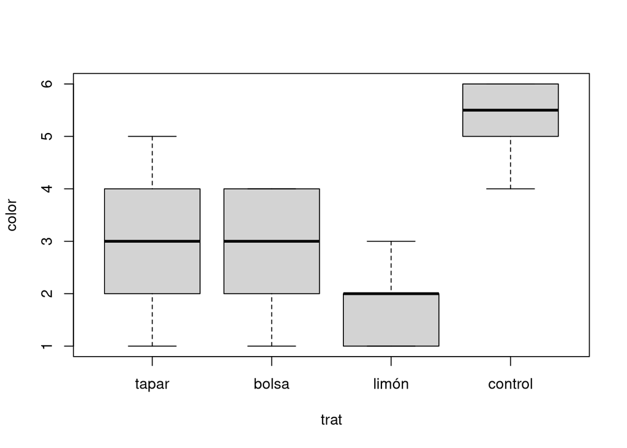

```r
boxplot(color~trat,ylab="color")
```

Se observa que los puntajes de color son mucho más bajos en los tres tratamientos que en el del grupo de control (en el que no se hace nada). Cuando se aplicó limón estos puntajes tienden a ser más bajos que cuando se cubrió de alguna forma. También se observa que los dos tratamientos en que se cubrió la manzana producen resultados muy similares.

Complementariamente, puede construirse una tabla con las medias de la respuesta por tratamiento y llamar al objeto así construido `m`.

```r
m=tapply(color,trat,mean)
round(m,2)
```

```
##   tapar   bolsa   limón control
##     3.2     2.8     1.8     5.4
```

Además, puede construirse una tabla que contenga las varianzas de la respuesta por tratamiento y llamar a este objeto `v`.

```r
v=tapply(color,trat,var)
round(v,2)
```

```
##   tapar   bolsa   limón control
##    1.73    1.07    0.62    0.49
```

Es posible también obtener la media general de la respuesta y agregarla al boxplot utilizando la sintaxis `abline(h=media, col=2)`, así como también agregarle las medias de los cuatro tratamientos (el de control es *placebo*) mediante la sintaxis `points(1:4,m,col=4,pch=”-“,cex=2)`.

```r
boxplot(color~trat,ylab="color")
(media=mean(color))
```

```
## [1] 3.3
```

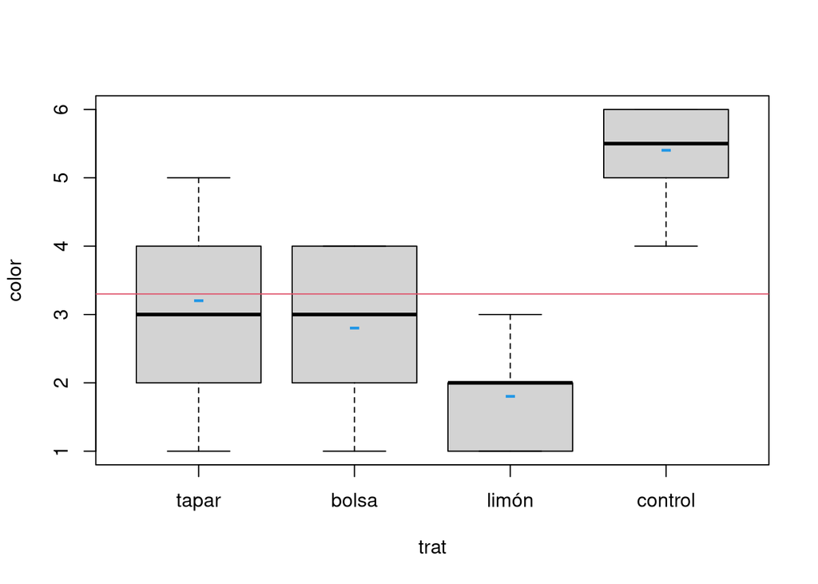

```r
abline(h=media, col=2)
points(1:4,m,col=4,pch="-",cex=2)
```

Además del análisis exploratorio anterior, es de especial interés determinar los efectos muestrales de cada tratamiento a partir de la tabla de medias y comparar tales resultados con lo que se observa gráficamente. Recuérdese que el efecto del tratamiento j-ésimo se define como: $\tau_j=\mu_j-\mu$. Cada efecto se puede estimar como: $\hat{\tau}_j=\bar{y}_j-\bar{y}$, donde $\bar{y}$ representa la media general de la respuesta y $\bar{y}_j$ la media de la respuesta en el j-éstimo tratamiento.

```r
#EFECTOS
ef=m-media
ef
```

```
##   tapar   bolsa   limón control
##    -0.1    -0.5    -1.5     2.1
```

```r
#SUMA DE EFECTOS
sum(ef) #Aunque no da exactamente cero por motivos de cálculo computacional, la suma de los efectos se aproxima a cero empíricamente y debe ser cero teóricamente por su misma construcción
```

```
## [1] 1.110223e-15
```

Los resultados numéricos coinciden con los gráficos, puesto que los valores negativos concuerdan con aquellas medias que están por debajo de la media general y el valor positivo del control concuerda con el gráfico en que su media está por encima de la media general.

El significado de cada uno de los valores obtenidos para los efectos muestrales es el siguiente: el control tiene una media que está 2.1 puntos sobre la media general, por lo que se dice que el control tiene el efecto de subir la media 2.1 puntos. El limón produce una media 1.5 puntos por debajo de la media general, es decir, tiene el efecto de bajar la media 1.5 puntos. Similarmente, los dos tratamientos en que se cubre tienen un leve efecto sobre la media ya que ambos bajan la media muy poco.

Es recomendable estimar la varianza del error (CME) a partir de la tabla de variancias antes construida. La estimación debe ser la media ponderada de las varianzas en los tratamientos, las cuales se ponderan con los grados de libertad, sin embargo, en este caso se tiene el mismo número de réplicas en todos los tratamientos, por lo que basta hacer un promedio simple de las variancias.

```r
n=table(trat)
n
```

```
## trat
##   tapar   bolsa   limón control
##      10      10      10      10
```

```r
# CME= SCE/n-p
v1=sum((n-1)*v)/(sum(n)-4)
round(v1,2)
```

```
## [1] 0.98
```

```r
v2=mean(v)
round(v2,2)
```

```
## [1] 0.98
```

¿Por qué la varianza del error es igual a la varianza de la respuesta en cada tratamiento?

$$e_{ij}= y_{ij}-\mu_{j}=> V(e/x_j)=
V(y/x_j)-\mu_{j}= V(y/x_j)$$

En este caso, $\mu_{j}$ aparece como una constante que no va a modificar las varianzas de los tratamientos y, a causa del supuesto de homogeneidad de varianzas, esta varianza del error sería el mejor estimador.